# Module 4: Data Visualization

Notice a warning about a row with missing values. This is a warning of a potential issue about the data we may want to investigate further. This is not an error message. The code ran perfectly fine and generated the intended plot. If the warnings distract you, then we can add an argument `na.rm = TRUE` in the `geom` layer or we can disable the warning using the code chunk option `#| warning: false`. Both are illustrated below. So as not to complicate the code, we tend to use the code chunk option `#| warning: false` to hide the warning rather than add the `na.rm = TRUE` argument to the code.

```r
ggplot(hawks, aes(x = wing, y = tail)) +
  geom_point(na.rm = TRUE)  # use argument to remove observations before plotting
```

[output not shown]

```r
# the code chunk option `#| warning: false` disables warning
ggplot(hawks, aes(x = wing, y = tail)) +
  geom_point()  # no longer need to use na.rm = TRUE
```

[output not shown]

6. We can account for additional potential lurking variables such as `age` or `species` by layering additional **aesthetics** onto our plot and see if they reveal any additional patterns or insight.

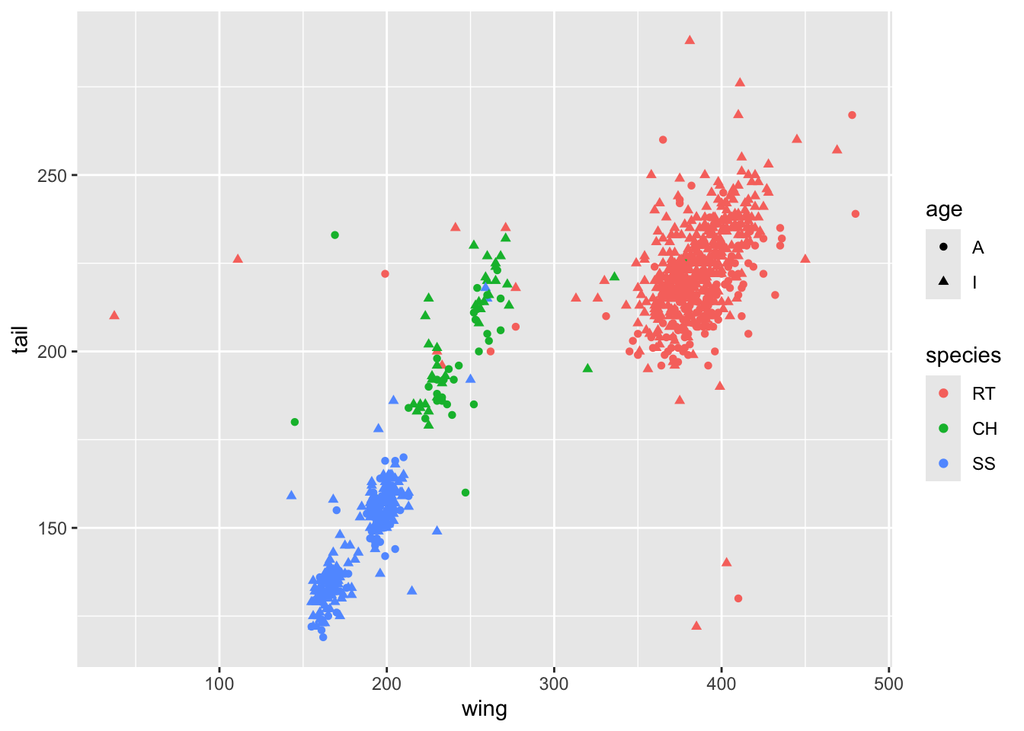

```r
ggplot(hawks, aes(x = wing,
                  y = tail,
                  color = species,  # include color aesthetic
                  shape = age)) +  # include shape aesthetic
  geom_point()  # add geom layer
```

Below is an example of how we can store a foundation and then add layers to customize the plot.

```r
# no output generated since we have
# stored previous plot to gghawk
gghawk <- ggplot(hawks, aes(x = wing,
                            y = tail,
                            color = species,  # include color aesthetic
                            shape = age)) +  # include shape aesthetic
  geom_point()  # add geom layer
```

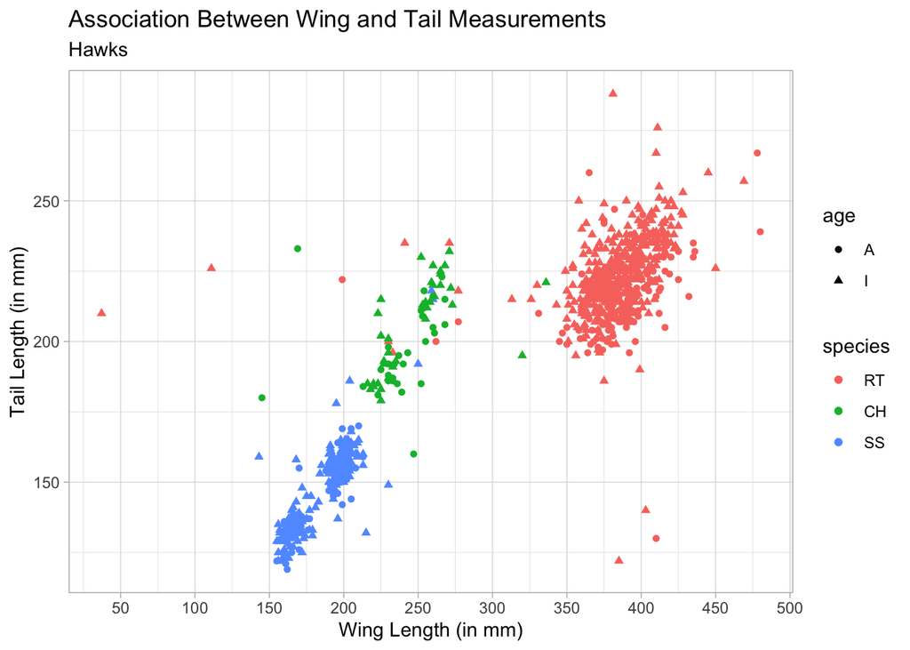

```r
gghawk +
  scale_x_continuous(breaks = seq(0, 500, by = 50)) +  # customize scale on x-axis
  scale_y_continuous(breaks = seq(0, 300, by = 50)) +  # customize scale on y-axis
  labs(  # customize labels
    title = "Association Between Wing and Tail Measurements",
    subtitle = "Hawks",
    x = "Wing Length (in mm)",
    y = "Tail Length (in mm)") +
  theme_light()  # use a custom theme
```

**Note**

A `theme` is a customized style that changes the overall appearance of our graphic in non-data related ways.`ggplot2` provides a number of built-in themes. Some of the built-in themes include:

- `theme_gray`: The default theme. Gray background and white grid lines.
- `theme_bw`: White background and gray grid lines.
- `theme_classic`: White background and no grid lines.
- `theme_minimal`: White background, no grid lines, no axis lines.
- `theme_light`: White background, gray grid lines, and a box around the plotting region.

## Common Geoms

There are many geometric objects available in **ggplot2**. A complete list may be (currently) found at https://ggplot2.tidyverse.org/reference/. A partial list of geometric objects that are frequently used are found below.

| dimensionality | geometry | purpose |
| --- | --- | --- |
| 1d | `geom_bar` | Draws a bar chart. |
| 1d | `geom_density` | Draws a density plot. |
| 1d | `geom_histogram` | Draws a histogram. |
| 1d | `geom_boxplot` | Draws a boxplot. |
| 1d | `geom_violin` | Draws a violin plot. |
| 1d | `geom_qq` | Draws a quantile-quantile plot. |
| 2d | `geom_point` | Draws points. Used for scatter plots. |
| 2d | `geom_path`, `geom_line` | Connects observations. Used for line plots. |
| 2d | `geom_segment` | Draws straight lines between points. |
| 2d | `geom_curve` | Draws curved lines between points. |
| 2d | `geom_smooth` | Draws a ‘smooth’ fitted model of the data. |
| 2d | `geom_density2d` | Draws 2d contours of density estimate for two variables. |
| 2d | `geom_density2d_filled` | Draws 2d contours of density estimate for two variables with colors. |
| 3d | `geom_contour` | Draws 2d contours of 3d data. |
| 3d | `geom_contour_filled` | Draws 2d contours of 3d data (colored). |
| NA | `geom_abline`, `geom_hline`, `geom_vline` | Draws diagonal, horizontal, and vertical lines. |